# LLC tank pre-design calculations

- Voltage Gain – Theoretical Overview
- Inputs and Specifications
- Transfo ratio and Voltage Gain
- Lm, Lr, Cr tank
- Simulation
- References

### Voltage Gain – Theoretical Overview

[figure not shown]

**Figure 1:** The simplified schematic and the equivalent small-signal AC model

The voltage gain function (normalized) expression is:

$$ M_g = \left| \frac{L_n \cdot f_n^2}{\left[(L_n + 1) \cdot f_n^2 - 1\right] + j\left[(f_n^2 - 1) \cdot f_n \cdot Q_e \cdot L_n\right]} \right| $$

With:

$$ L_n = \frac{L_m}{L_r}, \quad Q_e = \frac{\sqrt{\frac{L_r}{C_r}}}{R_e}, \quad f_n = \frac{f_{sw}}{f_0}, \quad f_0 = \frac{1}{2\pi\sqrt{L_r C_r}} $$

See page 3 formula (23) [1].  
You can found all formula of this chapeter in the same ref

[figure not shown]

### Inputs and Specifications

$ \begin{aligned} V_{In_{min}} &= 360 \; \;\textrm{(v)} \\[10pt] V_{In_{nom}} &= 380 \; \;\textrm{(v)} \\[10pt] V_{In_{max}} &= 400 \; \;\textrm{(v)} \end{aligned} $

$ \begin{aligned} \mathrm{Vo}_{min} &= 42 \; \;\textrm{(v)} \\[10pt] \mathrm{Vo}_{nom} &= 48 \; \;\textrm{(v)} \\[10pt] \mathrm{Vo}_{max} &= 54 \; \;\textrm{(v)} \end{aligned} $

$ \begin{aligned} \mathrm{Power} &= 1200 \; \;\textrm{(w)} \\[10pt] f_{nom} &= 100000.000 \; \;\textrm{(Hz)} \end{aligned} $

**Inputs data**

```
{'V_In_min': 360.0,
 'V_In_nom': 380.0,
 'V_In_max': 400.0,
 'Vo_min': 42.0,
 'Vo_nom': 48.0,
 'Vo_max': 54.0,
 'Power': 1200.0,
 'f_nom': 100000.0}
```

### Transfo ratio and Voltage Gain

$ \begin{aligned} n &= \frac{ V_{In_{nom}} }{ \mathrm{Vo}_{nom} \cdot 2 } = \frac{ 380 }{ 48 \cdot 2 } &= 3.958 \end{aligned} $

Choose an integer value to simplify the transformer design.

$ \begin{aligned} n &= \operatorname{round} \left( n \right) = \operatorname{round} \left( 4 \right) &= 4 \end{aligned} $

$ \begin{aligned} \mathrm{Vf} &= 0.200 \; \;\textrm{(drop voltage in the mos)} \\[10pt] \mathrm{efficiency} &= 0.950 \; \;\textrm{(hypothesis)} \\[10pt] \mathrm{loss} &= 1 - \mathrm{efficiency} = 1 - 0.950 &= 0.050 \\[10pt] \mathrm{Io}_{nom} &= \frac{ \mathrm{Power} }{ \mathrm{Vo}_{nom} } = \frac{ 1200 }{ 48 } &= 25.000 \; \;\textrm{(A)} \\[10pt] V_{loss} &= \frac{ \frac{ \mathrm{Power} \cdot \mathrm{loss} }{ \mathrm{efficiency} } }{ \mathrm{Io}_{nom} } = \frac{ \frac{ 1200 \cdot 0.050 }{ 0.950 } }{ 25.000 } &= 2.526 \; \;\textrm{(v)} \end{aligned} $

$ \begin{aligned} \mathrm{margin} &= 0.010 \; \\[10pt] \mathrm{Mg}_{min} &= n \cdot \frac{ \mathrm{Vo}_{min} \cdot \left( 1 - \mathrm{margin} \right) + \mathrm{Vf} }{ \frac{ V_{In_{max}} }{ 2 } } \\&= 4 \cdot \frac{ 42 \cdot \left( 1 - 0.010 \right) + 0.200 }{ \frac{ 400 }{ 2 } } \\&= 0.836 \\[10pt] \end{aligned} $

$ \begin{aligned} \mathrm{Mg}_{max} &= n \cdot \frac{ \mathrm{Vo}_{max} \cdot \left( 1 + \mathrm{margin} \right) + \mathrm{Vf} + V_{loss} }{ \frac{ V_{In_{min}} }{ 2 } } \\&= 4 \cdot \frac{ 54 \cdot \left( 1 + 0.010 \right) + 0.200 + 2.526 }{ \frac{ 360 }{ 2 } } \\&= 1.273 \\[10pt] \\[10pt] \mathrm{Mg}_{max110} &= \mathrm{Mg}_{max} \cdot \left( \frac{ 110 }{ 100 } \right) \\&= 1.273 \cdot \left( \frac{ 110 }{ 100 } \right) \\&= 1.400 \\[10pt] \end{aligned} $

### Lm, Lr, Cr tank

Below we will use grid search to find the best values for `Ln` and `Qe`.

**The idea:**

We will select the `Ln` and `Qe` values that give an `Mg` value closest to `Mg_max110`.

**Top 6 (Ln, Qe) Combinations Matching `Mg_max110`**  
The following 6 values of `Ln` and `Qe` closely match the target voltage gain `Mg_max110`.  
These rows were selected based on the criterion that `Mg_ape` is nearly equal to `Mg_max110`.

$ \begin{aligned} \mathrm{Mg}_{max110} &= 1.400 \; \end{aligned} $

|  | Lnc | Qec | Lm_uH | Lr_uH | Cr_nF | fn_min | fn_max | fsw_min | fsw_max | Mg_ape |
| --- | --- | --- | --- | --- | --- | --- | --- | --- | --- | --- |
| 0 | 2.41 | 0.64 | 61.127 | 25.364 | 99.867314 | 0.6375 | 1.3790 | 63750.0 | 137900.0 | 1.400142 |
| 1 | 3.00 | 0.55 | 65.392 | 21.797 | 116.209238 | 0.6017 | 1.5622 | 60170.0 | 156220.0 | 1.400062 |
| 2 | 3.46 | 0.50 | 68.562 | 19.816 | 127.830162 | 0.5707 | 1.7698 | 57070.0 | 176980.0 | 1.399923 |
| 3 | 3.68 | 0.48 | 70.005 | 19.023 | 133.156419 | 0.5471 | 1.9035 | 54710.0 | 190350.0 | 1.400284 |
| 4 | 4.21 | 0.44 | 73.413 | 17.438 | 145.261548 | 0.5324 | 2.4133 | 53240.0 | 241330.0 | 1.400277 |
| 5 | 4.71 | 0.41 | 76.532 | 16.249 | 155.890441 | 0.5077 | 3.6928 | 50770.0 | 369280.0 | 1.400231 |

[figure not shown]

$ \begin{aligned} \mathrm{Lnc} &= 3 \; \\[10pt] \mathrm{Qec} &= 0.550 \; \end{aligned} $

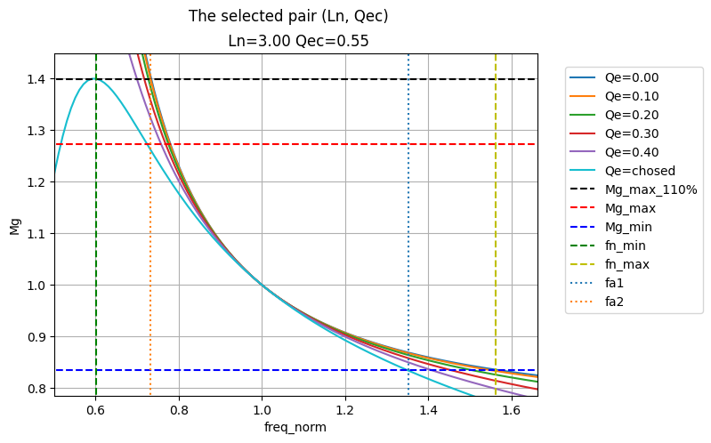

#### Equivalent resistor

$ \begin{aligned} \mathrm{Re}_{nom} &= 8 \cdot \left( n \right) ^{ 2 } \cdot \frac{ \mathrm{Vo}_{nom} }{ \left( \pi \right) ^{ 2 } \cdot \mathrm{Io}_{nom} } \\&= 8 \cdot \left( 4 \right) ^{ 2 } \cdot \frac{ 48 }{ \left( 3.142 \right) ^{ 2 } \cdot 25.000 } \\&= 24.901 \\[10pt] \\[10pt] \mathrm{Re}_{nom} &= \operatorname{round} \left( \mathrm{Re}_{nom} ,\ 3 \right) \\&= \operatorname{round} \left( 24.901 ,\ 3 \right) \\&= 24.901 \\[10pt] \\[10pt] \mathrm{Re}_{110} &= 8 \cdot \left( n \right) ^{ 2 } \cdot \frac{ \mathrm{Vo}_{nom} }{ \left( \pi \right) ^{ 2 } \cdot \mathrm{Io}_{nom} \cdot 1.1 } \\&= 8 \cdot \left( 4 \right) ^{ 2 } \cdot \frac{ 48 }{ \left( 3.142 \right) ^{ 2 } \cdot 25.000 \cdot 1.1 } \\&= 22.637 \\[10pt] \\[10pt] P_{re_{110}} &= \frac{ \left( \frac{ V_{In_{nom}} }{ 2 } \right) ^{ 2 } }{ \mathrm{Re}_{nom} } \\&= \frac{ \left( \frac{ 380 }{ 2 } \right) ^{ 2 } }{ 24.901 } \\&= 1449.741 \\[10pt] \end{aligned} $

#### Lm, Lr, Cr values

$ \begin{aligned} \mathrm{Cr}_{nF} &= \frac{ 1 \times 10 ^ {9} }{ 2 \cdot \pi \cdot \mathrm{Qec} \cdot f_{nom} \cdot \mathrm{Re}_{nom} } \\&= \frac{ 1 \times 10 ^ {9} }{ 2 \cdot 3.142 \cdot 0.550 \cdot 100000.000 \cdot 24.901 } \\&= 116.209 \; \;\textrm{(nF)}\\[10pt] \end{aligned} $

$ \begin{aligned} \mathrm{Cr} &= 116.209 \; \\[10pt] \mathrm{Cr} &= \operatorname{round} \left( \mathrm{Cr} ,\ 3 \right) \\&= \operatorname{round} \left( 116.209 ,\ 3 \right) \\&= 116.209 \\[10pt] \end{aligned} $

$ \begin{aligned} \mathrm{Lr} &= \frac{ 1 }{ \left( 2 \cdot \pi \cdot f_{nom} \right) ^{ 2 } \cdot \mathrm{Cr} \cdot 1 \times 10 ^ {-9} } \\&= \frac{ 1 }{ \left( 2 \cdot 3.142 \cdot 100000.000 \right) ^{ 2 } \cdot 116.209 \cdot 1 \times 10 ^ {-9} } \\&= 0.000 \\[10pt] \\[10pt] \mathrm{Lr}_{uH} &= \mathrm{Lr} \cdot 1 \times 10 ^ {6} \\&= 0.000 \cdot 1 \times 10 ^ {6} \\&= 21.797 \; \;\textrm{(uH)}\\[10pt] \\[10pt] \mathrm{Lr}_{uH} &= \operatorname{round} \left( \mathrm{Lr}_{uH} ,\ 3 \right) \\&= \operatorname{round} \left( 21.797 ,\ 3 \right) \\&= 21.797 \\[10pt] \end{aligned} $

$ \begin{aligned} \mathrm{Lm} &= \mathrm{Lr} \cdot \mathrm{Lnc} \\&= 0.000 \cdot 3.000 \\&= 0.000 \\[10pt] \\[10pt] \mathrm{Lm}_{uH} &= \mathrm{Lm} \cdot 1 \times 10 ^ {6} \\&= 0.000 \cdot 1 \times 10 ^ {6} \\&= 65.392 \; \;\textrm{(uH)}\\[10pt] \end{aligned} $

$ \begin{aligned} L_{second_{uH}} &= \frac{ \mathrm{Lm}_{uH} }{ \left( n \right) ^{ 2 } } \\&= \frac{ 65.392 }{ \left( 4 \right) ^{ 2 } } \\&= 4.087 \; \;\textrm{(uH)}\\[10pt] \end{aligned} $

**Verification**

$ \begin{aligned} \mathrm{Qcal} &= \frac{ \sqrt { \frac{ \mathrm{Lr} }{ \mathrm{Cr} \cdot 1 \times 10 ^ {-9} } } }{ \mathrm{Re}_{110} \cdot 1.1 } = \frac{ \sqrt { \frac{ 0.000 }{ 116.209 \cdot 1 \times 10 ^ {-9} } } }{ 22.637 \cdot 1.1 } &= 0.550 \\[10pt] \mathrm{Qec} &= 0.550 \; \end{aligned} $

#### Fsw limites and primary secondary currents

$ \begin{aligned} \mathrm{fsw}_{min} &= \mathrm{fn}_{min} \cdot f_{nom} \\&= 0.602 \cdot 100000.000 \\&= 60170.000 \; \;\textrm{(Hz)}\\[10pt] \\[10pt] \mathrm{fsw}_{max} &= \mathrm{fn}_{max} \cdot f_{nom} \\&= 1.562 \cdot 100000.000 \\&= 156220.000 \; \;\textrm{(Hz)}\\[10pt] \\[10pt] \mathrm{wmin} &= 2 \cdot \pi \cdot \mathrm{fsw}_{min} \\&= 2 \cdot 3.142 \cdot 60170.000 \\&= 378059.260 \; \;\textrm{(rad/s)}\\[10pt] \\[10pt] \mathrm{wmax} &= 2 \cdot \pi \cdot \mathrm{fsw}_{max} \\&= 2 \cdot 3.142 \cdot 156220.000 \\&= 981559.209 \; \;\textrm{(rad/s)}\\[10pt] \end{aligned} $

$ \begin{aligned} \mathrm{Im}_{rms} &= 2 \cdot \sqrt { 2 } \cdot n \cdot \frac{ \mathrm{Vo}_{nom} }{ \pi \cdot \mathrm{Lm} \cdot \mathrm{wmin} } \\&= 2 \cdot \sqrt { 2 } \cdot 4 \cdot \frac{ 48 }{ 3.142 \cdot 0.000 \cdot 378059.260 } \\&= 6.992 \; \;\textrm{(Arms)}\\[10pt] \end{aligned} $

$ \begin{aligned} \mathrm{Io} &= 25.000 \; \;\textrm{(Arms)} \\[10pt] \mathrm{Ioe}_{rms} &= 1.1 \cdot \pi \cdot \frac{ \mathrm{Io} }{ n \cdot 2 \cdot \sqrt { 2 } } \\&= 1.1 \cdot 3.142 \cdot \frac{ 25.000 }{ 4 \cdot 2 \cdot \sqrt { 2 } } \\&= 7.636 \; \;\textrm{(Arms @ 110%)}\\[10pt] \\[10pt] \mathrm{Ios}_{rms} &= \mathrm{Ioe}_{rms} \cdot n \\&= 7.636 \cdot 4 \\&= 30.545 \; \;\textrm{(Arms)}\\[10pt] \end{aligned} $

$ \begin{aligned} \mathrm{Ir}_{rms} &= \sqrt { \left( \mathrm{Im}_{rms} \right) ^{ 2 } + \left( \mathrm{Ioe} \right) ^{ 2 } } \\&= \sqrt { \left( 6.992 \right) ^{ 2 } + \left( 7.636 \right) ^{ 2 } } \\&= 10.354 \; \;\textrm{(Arms)}\\[10pt] \end{aligned} $

**Output data**

```
{'Lnc': 3.0,
 'Qec': 0.55,
 'Cr_nF': 116.209,
 'n': 4.0,
 'Lr_uH': 21.797,
 'Lm_uH': 65.392,
 'fsw_min': 60170.0,
 'fsw_max': 156220.0,
 'Im_rms': 6.992,
 'Io': 25.0,
 'Ioe_rms': 7.636,
 'Ios_rms': 30.545,
 'Ir_rms': 10.354,
 'L_second_uH': 4.087,
 'Re_nom': 24.901,
 'Re_110': 22.637,
 'Cr': 1.16209e-07,
 'Lr': 2.1796999999999998e-05,
 'Lm': 6.539199999999999e-05}
```

## Simulations

**AC simulation of the LLC gain**

[figure not shown]

**Figure 2:** AC response of the LLC tank, for load is 10, 20, 40, 60, 80 and 100% of Re_110

The frequency response is close to our calculated target for frequencies in the range [F_min, F_max].

you can donwload the simulation file here

**Simple simulation (nominal)**

[figure not shown]

**Figure 3:** The simulation of the LLC tank

The output is around 48V for an input of 380V and 100kHz (nominal).  
The Lm current is close to a sine wave form as expected (resonanance).

[you can donwload the simulation file here](https://github.com/BOAB235/Design_of_1200W_LLC_DCDC/tree/main/03_hw_design/01_design_justification/01_llc_tank/02_simulation/04_simple_model)

## References

[1] Hong Huang, *Designing an LLC Resonant Half-Bridge Power Converter*. Available: https://bbs.dianyuan.com/upload/community/2013/12/01/1385867010-65563.pdf [2]  
Code [Python notebook used to make this PDF](https://github.com/BOAB235/Design_of_1200W_LLC_DCDC/blob/main/03_hw_design/01_design_justification/01_llc_tank/01_LLC_48v_LLC_tank_design_note_v2.ipynb)